# SENDY LOGISTICS

THE TITANS

19/07/2021

## **DATA UNDERSTANDING**

Sendy ltd aims at taking away the uncertainty of conventional delivery methods. The company aims at making the process simple, transparent and secure. The main goal is to ensure timely delivery of orders, ensure the goods are safe in transit all this time ensuring they share the time it takes for the order to arrive.

## **METRIC OF SUCCESS**

The project will be deemed a successful project if we are able to perform forecasting on given data to come up with predictions on the estimated time of arrival given various features and variables. Being able to come up with the relevant features for this particular project by performing feature selection since it helps in improving the prediction performance and allows for faster and effective predictors.

## **CONTEXT**

The commercial activity of transporting goods to customers is known as logistics. For any logistics company, being timely is a key factor in establishing a competitive advantage over the rest of the competition and ensuring we remain industry leaders while at it. A logistic company should also ensure management of their fleet and ensure timely deliveries of the orders entrusted to them. Sendy is one such company.

## **EXPERIMENTAL DESIGN**

- Import the relevant libraries that we will use in our analysis
- Read and explore the dataset we will use for our project
- Define the appropriateness of the available data with regards to the project
- Find and deal with outliers, anomalies, and missing data within the dataset.
- Perform univariate and bivariate analysis while recording our observations.
- Implementing the solution using various supervised machine learning algorithms
- Challenging the Solution
- Follow up Questions

## **DATA RELEVANCE**

Our data is very relevant since most of our variables contribute highly to the efficiency in delivery services such as Distance between two points.

## **READING THE DATASET**

```r
# Attaching the packages needed
library(dplyr)
```

```r
library(tidyr)
library(ggplot2)
library(lubridate)
library(lattice)
library(psych)
library(tidyverse)
library(caret)
library(stats)
library(Amelia)
library(tibbletime)
library(tibble)
library(CatEncoders)
# Reading the data
sendy <- read.csv("D:/Downloads/Train.csv")%>% as_tibble()
```

```r
# Previewing the top of the dataset
head(sendy)
```

```
## # A tibble: 6 x 29
##   Order.No  User.Id Vehicle.Type Platform.Type Personal.or.Bus~ Placement...Day~
##   <chr>     <chr>   <chr>                <int> <chr>                       <int>
## 1 Order_No~ User_I~ Bike                     3 Business                        9
## 2 Order_No~ User_I~ Bike                     3 Personal                       12
## 3 Order_No~ User_I~ Bike                     3 Business                       30
## 4 Order_No~ User_I~ Bike                     3 Business                       15
## 5 Order_No~ User_I~ Bike                     1 Personal                       13
## 6 Order_No~ User_I~ Bike                     3 Business                       14
## # ... with 23 more variables: Placement...Weekday..Mo...1. <int>,
## #   Placement...Time <chr>, Confirmation...Day.of.Month <int>,
## #   Confirmation...Weekday..Mo...1. <int>, Confirmation...Time <chr>,
## #   Arrival.at.Pickup...Day.of.Month <int>,
## #   Arrival.at.Pickup...Weekday..Mo...1. <int>, Arrival.at.Pickup...Time <chr>,
## #   Pickup...Day.of.Month <int>, Pickup...Weekday..Mo...1. <int>,
## #   Pickup...Time <chr>, Arrival.at.Destination...Day.of.Month <int>,
## #   Arrival.at.Destination...Weekday..Mo...1. <int>,
## #   Arrival.at.Destination...Time <chr>, Distance..KM. <int>,
## #   Temperature <dbl>, Precipitation.in.millimeters <dbl>, Pickup.Lat <dbl>,
## #   Pickup.Long <dbl>, Destination.Lat <dbl>, Destination.Long <dbl>,
## #   Rider.Id <chr>, Time.from.Pickup.to.Arrival <int>
```

```r
# Look at the bottom of the dataset
tail(sendy)
```

```
## # A tibble: 6 x 29
##   Order.No  User.Id Vehicle.Type Platform.Type Personal.or.Bus~ Placement...Day~
##   <chr>     <chr>   <chr>                <int> <chr>                       <int>
## 1 Order_No~ User_I~ Bike                     3 Business                        2
## 2 Order_No~ User_I~ Bike                     3 Personal                       20
## 3 Order_No~ User_I~ Bike                     3 Business                       13
## 4 Order_No~ User_I~ Bike                     3 Business                        7
## 5 Order_No~ User_I~ Bike                     1 Personal                        4
## 6 Order_No~ User_I~ Bike                     3 Business                       26
## # ... with 23 more variables: Placement...Weekday..Mo...1. <int>,
## #   Placement...Time <chr>, Confirmation...Day.of.Month <int>,
## #   Confirmation...Weekday..Mo...1. <int>, Confirmation...Time <chr>,
## #   Arrival.at.Pickup...Day.of.Month <int>,
## #   Arrival.at.Pickup...Weekday..Mo...1. <int>, Arrival.at.Pickup...Time <chr>,
## #   Pickup...Day.of.Month <int>, Pickup...Weekday..Mo...1. <int>,
## #   Pickup...Time <chr>, Arrival.at.Destination...Day.of.Month <int>,
## #   Arrival.at.Destination...Weekday..Mo...1. <int>,
## #   Arrival.at.Destination...Time <chr>, Distance..KM. <int>,
## #   Temperature <dbl>, Precipitation.in.millimeters <dbl>, Pickup.Lat <dbl>,
## #   Pickup.Long <dbl>, Destination.Lat <dbl>, Destination.Long <dbl>,
## #   Rider.Id <chr>, Time.from.Pickup.to.Arrival <int>
```

```r
# Looking at the datatypes of our columns
lapply(sendy,class)
```

```
## $Order.No
## [1] "character"
##
## $User.Id
## [1] "character"
##
## $Vehicle.Type
## [1] "character"
##
## $Platform.Type
## [1] "integer"
##
## $Personal.or.Business
## [1] "character"
##
## $Placement...Day.of.Month
## [1] "integer"
##
## $Placement...Weekday..Mo...1.
## [1] "integer"
##
## $Placement...Time
## [1] "character"
##
## $Confirmation...Day.of.Month
## [1] "integer"
##
## $Confirmation...Weekday..Mo...1.
## [1] "integer"
##
## $Confirmation...Time
## [1] "character"
##
## $Arrival.at.Pickup...Day.of.Month
## [1] "integer"
##
## $Arrival.at.Pickup...Weekday..Mo...1.
## [1] "integer"
##
## $Arrival.at.Pickup...Time
```

[output cut: 31 more lines]

```
##
## $Pickup.Long
## [1] "numeric"
##
## $Destination.Lat
## [1] "numeric"
##
## $Destination.Long
## [1] "numeric"
##
## $Rider.Id
## [1] "character"
##
## $Time.from.Pickup.to.Arrival
## [1] "integer"
```

```r
# Look at the structure
str(sendy)
```

```
## tibble [21,201 x 29] (S3: tbl_df/tbl/data.frame)
##  $ Order.No                                 : chr [1:21201] "Order_No_4211" "Order_No_25375" "Order_No_1899" "Order_No_9336" ...
##  $ User.Id                                  : chr [1:21201] "User_Id_633" "User_Id_2285" "User_Id_265" "User_Id_1402" ...
##  $ Vehicle.Type                             : chr [1:21201] "Bike" "Bike" "Bike" "Bike" ...
##  $ Platform.Type                            : int [1:21201] 3 3 3 3 1 3 3 3 3 3 ...
##  $ Personal.or.Business                     : chr [1:21201] "Business" "Personal" "Business" "Business" ...
##  $ Placement...Day.of.Month                 : int [1:21201] 9 12 30 15 13 14 9 11 30 23 ...
##  $ Placement...Weekday..Mo...1.             : int [1:21201] 5 5 2 5 1 5 5 1 2 5 ...
##  $ Placement...Time                         : chr [1:21201] "9:35:46 AM" "11:16:16 AM" "12:39:25 PM" "9:25:34 AM" ...
##  $ Confirmation...Day.of.Month              : int [1:21201] 9 12 30 15 13 14 9 11 30 23 ...
##  $ Confirmation...Weekday..Mo...1.          : int [1:21201] 5 5 2 5 1 5 5 1 2 5 ...
##  $ Confirmation...Time                      : chr [1:21201] "9:40:10 AM" "11:23:21 AM" "12:42:44 PM" "9:26:05 AM" ...
##  $ Arrival.at.Pickup...Day.of.Month         : int [1:21201] 9 12 30 15 13 14 9 11 30 23 ...
##  $ Arrival.at.Pickup...Weekday..Mo...1.     : int [1:21201] 5 5 2 5 1 5 5 1 2 5 ...
##  $ Arrival.at.Pickup...Time                 : chr [1:21201] "10:04:47 AM" "11:40:22 AM" "12:49:34 PM" "9:37:56 AM" ...
##  $ Pickup...Day.of.Month                    : int [1:21201] 9 12 30 15 13 14 9 11 30 23 ...
##  $ Pickup...Weekday..Mo...1.                : int [1:21201] 5 5 2 5 1 5 5 1 2 5 ...
##  $ Pickup...Time                            : chr [1:21201] "10:27:30 AM" "11:44:09 AM" "12:53:03 PM" "9:43:06 AM" ...
##  $ Arrival.at.Destination...Day.of.Month    : int [1:21201] 9 12 30 15 13 14 9 11 30 23 ...
##  $ Arrival.at.Destination...Weekday..Mo...1.: int [1:21201] 5 5 2 5 1 5 5 1 2 5 ...
##  $ Arrival.at.Destination...Time            : chr [1:21201] "10:39:55 AM" "12:17:22 PM" "1:00:38 PM" "10:05:27 AM" ...
##  $ Distance..KM.                            : int [1:21201] 4 16 3 9 9 9 5 3 9 14 ...
##  $ Temperature                              : num [1:21201] 20.4 26.4 NA 19.2 15.4 27.2 20.3 28.7 NA 24.6 ...
##  $ Precipitation.in.millimeters             : num [1:21201] NA NA NA NA NA NA NA NA NA NA ...
##  $ Pickup.Lat                               : num [1:21201] -1.32 -1.35 -1.31 -1.28 -1.27 ...
##  $ Pickup.Long                              : num [1:21201] 36.8 36.9 36.8 36.8 36.8 ...
##  $ Destination.Lat                          : num [1:21201] -1.3 -1.3 -1.3 -1.26 -1.3 ...
##  $ Destination.Long                         : num [1:21201] 36.8 36.8 36.8 36.8 36.8 ...
##  $ Rider.Id                                 : chr [1:21201] "Rider_Id_432" "Rider_Id_856" "Rider_Id_155" "Rider_Id_855" ...
##  $ Time.from.Pickup.to.Arrival              : int [1:21201] 745 1993 455 1341 1214 3191 1380 646 3398 3439 ...
```

```r
# number of records in the dataset
dim(sendy)
```

```
## [1] 21201    29
```

```r
# Looking at the summary of the data
summary(sendy)
```

```
##    Order.No           User.Id          Vehicle.Type       Platform.Type
##  Length:21201       Length:21201       Length:21201       Min.   :1.000
##  Class :character   Class :character   Class :character   1st Qu.:3.000
##  Mode  :character   Mode  :character   Mode  :character   Median :3.000
##                                                           Mean   :2.752
##                                                           3rd Qu.:3.000
##                                                           Max.   :4.000
##
##  Personal.or.Business Placement...Day.of.Month Placement...Weekday..Mo...1.
##  Length:21201         Min.   : 1.00            Min.   :1.00
##  Class :character     1st Qu.: 8.00            1st Qu.:2.00
##  Mode  :character     Median :15.00            Median :3.00
##                       Mean   :15.65            Mean   :3.24
##                       3rd Qu.:23.00            3rd Qu.:5.00
##                       Max.   :31.00            Max.   :7.00
##
##  Placement...Time   Confirmation...Day.of.Month Confirmation...Weekday..Mo...1.
##  Length:21201       Min.   : 1.00               Min.   :1.00
##  Class :character   1st Qu.: 8.00               1st Qu.:2.00
##  Mode  :character   Median :15.00               Median :3.00
##                     Mean   :15.65               Mean   :3.24
##                     3rd Qu.:23.00               3rd Qu.:5.00
##                     Max.   :31.00               Max.   :7.00
##
##  Confirmation...Time Arrival.at.Pickup...Day.of.Month
##  Length:21201        Min.   : 1.00
##  Class :character    1st Qu.: 8.00
##  Mode  :character    Median :15.00
##                      Mean   :15.65
##                      3rd Qu.:23.00
##                      Max.   :31.00
##
##  Arrival.at.Pickup...Weekday..Mo...1. Arrival.at.Pickup...Time
##  Min.   :1.00                         Length:21201
##  1st Qu.:2.00                         Class :character
##  Median :3.00                         Mode  :character
##  Mean   :3.24
##  3rd Qu.:5.00
##  Max.   :7.00
##
```

[output cut: 33 more lines]

```
##  Min.   :36.65   Min.   :-1.430   Min.   :36.61    Length:21201
##  1st Qu.:36.78   1st Qu.:-1.301   1st Qu.:36.79    Class :character
##  Median :36.81   Median :-1.284   Median :36.81    Mode  :character
##  Mean   :36.81   Mean   :-1.283   Mean   :36.81
##  3rd Qu.:36.83   3rd Qu.:-1.261   3rd Qu.:36.83
##  Max.   :36.99   Max.   :-1.030   Max.   :37.02
##
##  Time.from.Pickup.to.Arrival
##  Min.   :   1
##  1st Qu.: 882
##  Median :1369
##  Mean   :1557
##  3rd Qu.:2040
##  Max.   :7883
##
```

## Data Tidying

```r
# get column names
colnames(sendy)
```

```
##  [1] "Order.No"
##  [2] "User.Id"
##  [3] "Vehicle.Type"
##  [4] "Platform.Type"
##  [5] "Personal.or.Business"
##  [6] "Placement...Day.of.Month"
##  [7] "Placement...Weekday..Mo...1."
##  [8] "Placement...Time"
##  [9] "Confirmation...Day.of.Month"
## [10] "Confirmation...Weekday..Mo...1."
## [11] "Confirmation...Time"
## [12] "Arrival.at.Pickup...Day.of.Month"
## [13] "Arrival.at.Pickup...Weekday..Mo...1."
## [14] "Arrival.at.Pickup...Time"
## [15] "Pickup...Day.of.Month"
## [16] "Pickup...Weekday..Mo...1."
## [17] "Pickup...Time"
## [18] "Arrival.at.Destination...Day.of.Month"
## [19] "Arrival.at.Destination...Weekday..Mo...1."
## [20] "Arrival.at.Destination...Time"
## [21] "Distance..KM."
## [22] "Temperature"
## [23] "Precipitation.in.millimeters"
## [24] "Pickup.Lat"
## [25] "Pickup.Long"
## [26] "Destination.Lat"
## [27] "Destination.Long"
## [28] "Rider.Id"
## [29] "Time.from.Pickup.to.Arrival"
```

```r
# Checking the completeness of the data at hand
colSums(is.na(sendy))
```

```
##                                  Order.No
##                                         0
##                                   User.Id
##                                         0
##                              Vehicle.Type
##                                         0
##                             Platform.Type
##                                         0
##                      Personal.or.Business
##                                         0
##                  Placement...Day.of.Month
##                                         0
##              Placement...Weekday..Mo...1.
##                                         0
##                          Placement...Time
##                                         0
##               Confirmation...Day.of.Month
##                                         0
##           Confirmation...Weekday..Mo...1.
##                                         0
##                       Confirmation...Time
##                                         0
##          Arrival.at.Pickup...Day.of.Month
##                                         0
##      Arrival.at.Pickup...Weekday..Mo...1.
##                                         0
##                  Arrival.at.Pickup...Time
##                                         0
##                     Pickup...Day.of.Month
##                                         0
##                 Pickup...Weekday..Mo...1.
##                                         0
##                             Pickup...Time
##                                         0
##     Arrival.at.Destination...Day.of.Month
##                                         0
## Arrival.at.Destination...Weekday..Mo...1.
##                                         0
##             Arrival.at.Destination...Time
##                                         0
##                             Distance..KM.
##                                         0
##                               Temperature
##                                      4366
##              Precipitation.in.millimeters
##                                     20649
##                                Pickup.Lat
##                                         0
##                               Pickup.Long
##                                         0
##                           Destination.Lat
##                                         0
##                          Destination.Long
##                                         0
##                                  Rider.Id
##                                         0
##               Time.from.Pickup.to.Arrival
##                                         0
```

```r
# Dropping the Precipitation column
sendy = subset(sendy, select = -c(Precipitation.in.millimeters, Vehicle.Type) )
```

```r
# Mean imputation of temp column
sendy$Temperature[is.na(sendy$Temperature)] <- mean(sendy$Temperature, na.rm = TRUE)
```

```r
# Checking the completeness of the data after handling
colSums(is.na(sendy))
```

```
##                                  Order.No
##                                         0
##                                   User.Id
##                                         0
##                             Platform.Type
##                                         0
##                      Personal.or.Business
##                                         0
##                  Placement...Day.of.Month
##                                         0
##              Placement...Weekday..Mo...1.
##                                         0
##                          Placement...Time
##                                         0
##               Confirmation...Day.of.Month
##                                         0
##           Confirmation...Weekday..Mo...1.
##                                         0
##                       Confirmation...Time
##                                         0
##          Arrival.at.Pickup...Day.of.Month
##                                         0
##      Arrival.at.Pickup...Weekday..Mo...1.
##                                         0
##                  Arrival.at.Pickup...Time
##                                         0
##                     Pickup...Day.of.Month
##                                         0
##                 Pickup...Weekday..Mo...1.
##                                         0
##                             Pickup...Time
##                                         0
##     Arrival.at.Destination...Day.of.Month
##                                         0
## Arrival.at.Destination...Weekday..Mo...1.
##                                         0
##             Arrival.at.Destination...Time
##                                         0
##                             Distance..KM.
##                                         0
##                               Temperature
##                                         0
##                                Pickup.Lat
##                                         0
##                               Pickup.Long
##                                         0
##                           Destination.Lat
##                                         0
##                          Destination.Long
##                                         0
##                                  Rider.Id
##                                         0
##               Time.from.Pickup.to.Arrival
##                                         0
```

```r
# Drop the remaining missing values
sendy = na.omit(sendy)
```

```r
# Checking the shape of the dataset
dim(sendy)
```

```
## [1] 21201    27
```

```r
# Checking the consistency of the data
df =duplicated(sendy)
sum(df)
```

```
## [1] 0
```

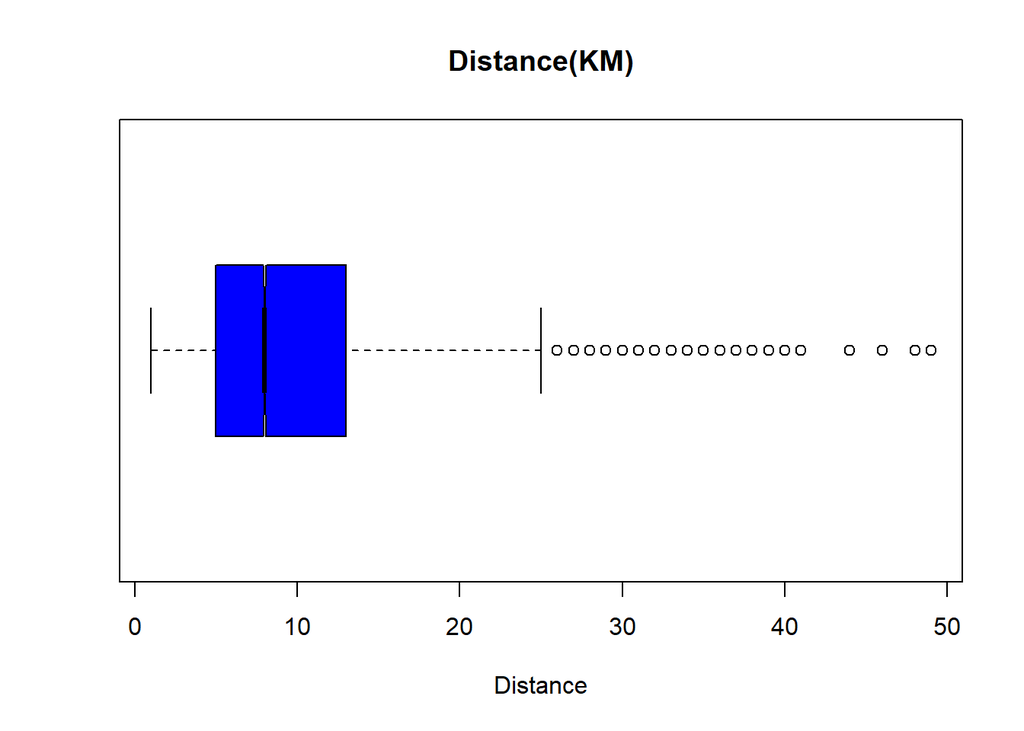

```r
boxplot(sendy$Distance..KM.,
         main = "Distance(KM)",
         col = "Blue",
         border = "Black",
         horizontal = T,
         notch = T,
         ylab = "",
         xlab = "Distance")
```

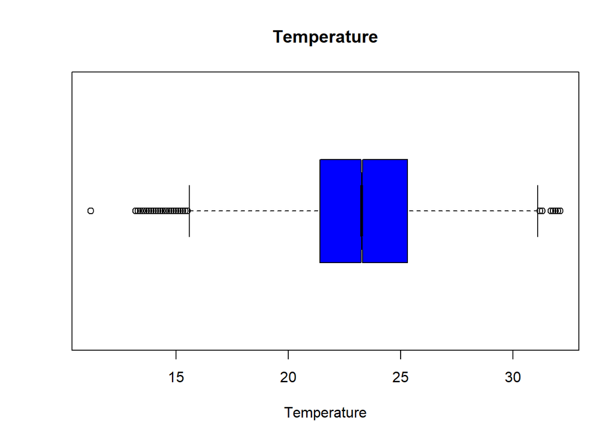

```r
boxplot(sendy$Temperature, na.rm=T,
         main = "Temperature",
         col = "Blue",
         border = "Black",
         horizontal = T,
         notch = T,
         ylab = "",
         xlab = "Temperature")
```

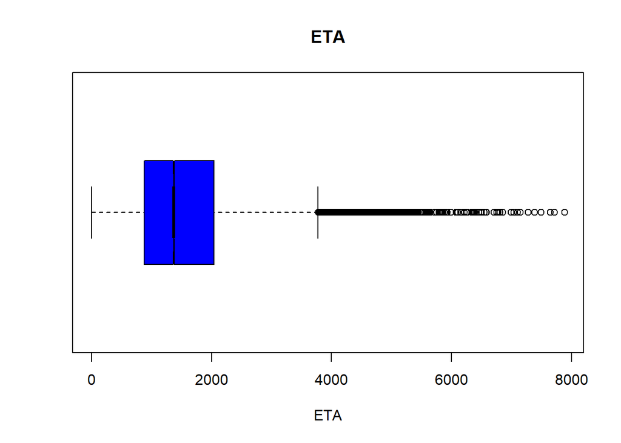

```r
boxplot(sendy$Time.from.Pickup.to.Arrival,
         main = "ETA",
         col = "Blue",
         border = "Black",
         horizontal = T,
         notch = T,
         ylab = "",
         xlab = "ETA")
```

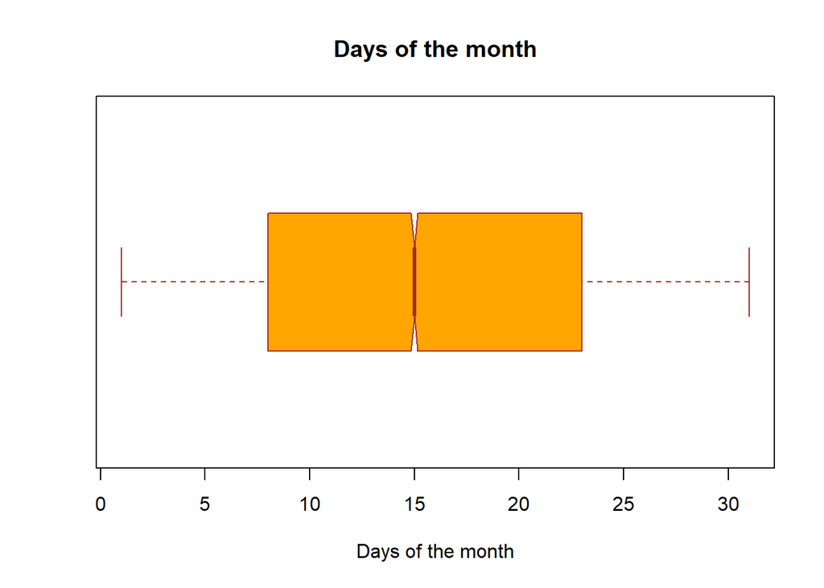

```r
boxplot(sendy$Placement...Day.of.Month,
         main = "Days of the month",
         col = "Orange",
         border = "Brown",
         horizontal = T,
         notch = T,
         ylab = "",
         xlab = "Days of the month")
```

The outliers we had in our data included those in the Temperature, Distance and Time from pickup to arrival columns. These can be explained by other geographical factors.

```r
sendy = sendy %>%
  mutate(Personal.or.Business = as.factor(Personal.or.Business),
         Platform.Type = as.factor(Platform.Type))
```

```r
sendy = sendy %>%
  mutate_at(vars(matches("weekday")), function(x) return(factor(x)))

sendy %>%
  select(contains("weekday")) %>%
  glimpse()
```

```
## Rows: 21,201
## Columns: 5
## $ Placement...Weekday..Mo...1.              <fct> 5, 5, 2, 5, 1, 5, 5, 1, 2, 5~
## $ Confirmation...Weekday..Mo...1.           <fct> 5, 5, 2, 5, 1, 5, 5, 1, 2, 5~
## $ Arrival.at.Pickup...Weekday..Mo...1.      <fct> 5, 5, 2, 5, 1, 5, 5, 1, 2, 5~
## $ Pickup...Weekday..Mo...1.                 <fct> 5, 5, 2, 5, 1, 5, 5, 1, 2, 5~
## $ Arrival.at.Destination...Weekday..Mo...1. <fct> 5, 5, 2, 5, 1, 5, 5, 1, 2, 5~
```

```r
sendy = sendy %>%
  mutate_at(vars(matches("Day")), function(x) return(factor(x)))

sendy %>%
  select(contains("Day")) %>%
  glimpse()
```

```
## Rows: 21,201
## Columns: 10
## $ Placement...Day.of.Month                  <fct> 9, 12, 30, 15, 13, 14, 9, 11~
## $ Placement...Weekday..Mo...1.              <fct> 5, 5, 2, 5, 1, 5, 5, 1, 2, 5~
## $ Confirmation...Day.of.Month               <fct> 9, 12, 30, 15, 13, 14, 9, 11~
## $ Confirmation...Weekday..Mo...1.           <fct> 5, 5, 2, 5, 1, 5, 5, 1, 2, 5~
## $ Arrival.at.Pickup...Day.of.Month          <fct> 9, 12, 30, 15, 13, 14, 9, 11~
## $ Arrival.at.Pickup...Weekday..Mo...1.      <fct> 5, 5, 2, 5, 1, 5, 5, 1, 2, 5~
## $ Pickup...Day.of.Month                     <fct> 9, 12, 30, 15, 13, 14, 9, 11~
## $ Pickup...Weekday..Mo...1.                 <fct> 5, 5, 2, 5, 1, 5, 5, 1, 2, 5~
## $ Arrival.at.Destination...Day.of.Month     <fct> 9, 12, 30, 15, 13, 14, 9, 11~
## $ Arrival.at.Destination...Weekday..Mo...1. <fct> 5, 5, 2, 5, 1, 5, 5, 1, 2, 5~
```

```r
sendy_hr = sendy %>%dplyr::rename(ETA = Time.from.Pickup.to.Arrival)%>%
mutate_at(vars(matches("Time")), function(x) return(format(strptime((x), "%I:%M:%S %p"), format = "%H"))) %>%
mutate_at(vars(matches("Time")), function(x) return(as.factor((x))))

sendy_hr %>%
  select(contains("Time")) %>%
  glimpse()
```

```
## Rows: 21,201
## Columns: 5
## $ Placement...Time              <fct> 09, 11, 12, 09, 09, 15, 09, 14, 11, 16, ~
## $ Confirmation...Time           <fct> 09, 11, 12, 09, 09, 15, 09, 14, 11, 17, ~
## $ Arrival.at.Pickup...Time      <fct> 10, 11, 12, 09, 10, 15, 09, 14, 12, 17, ~
## $ Pickup...Time                 <fct> 10, 11, 12, 09, 10, 15, 09, 14, 12, 17, ~
## $ Arrival.at.Destination...Time <fct> 10, 12, 13, 10, 10, 16, 10, 14, 13, 18, ~
```

```r
glimpse(sendy_hr)
```

```
## Rows: 21,201
## Columns: 27
## $ Order.No                                  <chr> "Order_No_4211", "Order_No_2~
## $ User.Id                                   <chr> "User_Id_633", "User_Id_2285~
## $ Platform.Type                             <fct> 3, 3, 3, 3, 1, 3, 3, 3, 3, 3~
## $ Personal.or.Business                      <fct> Business, Personal, Business~
## $ Placement...Day.of.Month                  <fct> 9, 12, 30, 15, 13, 14, 9, 11~
## $ Placement...Weekday..Mo...1.              <fct> 5, 5, 2, 5, 1, 5, 5, 1, 2, 5~
## $ Placement...Time                          <fct> 09, 11, 12, 09, 09, 15, 09, ~
## $ Confirmation...Day.of.Month               <fct> 9, 12, 30, 15, 13, 14, 9, 11~
## $ Confirmation...Weekday..Mo...1.           <fct> 5, 5, 2, 5, 1, 5, 5, 1, 2, 5~
## $ Confirmation...Time                       <fct> 09, 11, 12, 09, 09, 15, 09, ~
## $ Arrival.at.Pickup...Day.of.Month          <fct> 9, 12, 30, 15, 13, 14, 9, 11~
## $ Arrival.at.Pickup...Weekday..Mo...1.      <fct> 5, 5, 2, 5, 1, 5, 5, 1, 2, 5~
## $ Arrival.at.Pickup...Time                  <fct> 10, 11, 12, 09, 10, 15, 09, ~
## $ Pickup...Day.of.Month                     <fct> 9, 12, 30, 15, 13, 14, 9, 11~
## $ Pickup...Weekday..Mo...1.                 <fct> 5, 5, 2, 5, 1, 5, 5, 1, 2, 5~
## $ Pickup...Time                             <fct> 10, 11, 12, 09, 10, 15, 09, ~
## $ Arrival.at.Destination...Day.of.Month     <fct> 9, 12, 30, 15, 13, 14, 9, 11~
## $ Arrival.at.Destination...Weekday..Mo...1. <fct> 5, 5, 2, 5, 1, 5, 5, 1, 2, 5~
## $ Arrival.at.Destination...Time             <fct> 10, 12, 13, 10, 10, 16, 10, ~
## $ Distance..KM.                             <int> 4, 16, 3, 9, 9, 9, 5, 3, 9, ~
## $ Temperature                               <dbl> 20.40000, 26.40000, 23.25889~
## $ Pickup.Lat                                <dbl> -1.317755, -1.351453, -1.308~
## $ Pickup.Long                               <dbl> 36.83037, 36.89932, 36.84342~
## $ Destination.Lat                           <dbl> -1.300406, -1.295004, -1.300~
## $ Destination.Long                          <dbl> 36.82974, 36.81436, 36.82820~
## $ Rider.Id                                  <chr> "Rider_Id_432", "Rider_Id_85~
## $ ETA                                       <int> 745, 1993, 455, 1341, 1214, ~
```

### Performing EDA

#### Univariate Analysis

```r
# A dataset description
describe(sendy_hr)
```

```
##                                            vars     n     mean      sd   median
## Order.No*                                     1 21201 10601.00 6120.35 10601.00
## User.Id*                                      2 21201  1669.86  929.01  1728.00
## Platform.Type*                                3 21201     2.75    0.63     3.00
## Personal.or.Business*                         4 21201     1.18    0.38     1.00
## Placement...Day.of.Month*                     5 21201    15.65    8.80    15.00
## Placement...Weekday..Mo...1.*                 6 21201     3.24    1.57     3.00
## Placement...Time*                             7 21201     8.33    2.54     8.00
## Confirmation...Day.of.Month*                  8 21201    15.65    8.80    15.00
## Confirmation...Weekday..Mo...1.*              9 21201     3.24    1.57     3.00
## Confirmation...Time*                         10 21201     8.45    2.56     8.00
## Arrival.at.Pickup...Day.of.Month*            11 21201    15.65    8.80    15.00
## Arrival.at.Pickup...Weekday..Mo...1.*        12 21201     3.24    1.57     3.00
## Arrival.at.Pickup...Time*                    13 21201     7.66    2.56     8.00
## Pickup...Day.of.Month*                       14 21201    15.65    8.80    15.00
## Pickup...Weekday..Mo...1.*                   15 21201     3.24    1.57     3.00
## Pickup...Time*                               16 21201     7.87    2.55     8.00
## Arrival.at.Destination...Day.of.Month*       17 21201    15.65    8.80    15.00
## Arrival.at.Destination...Weekday..Mo...1.*   18 21201     3.24    1.57     3.00
## Arrival.at.Destination...Time*               19 21201     8.30    2.57     8.00
## Distance..KM.                                20 21201     9.51    5.67     8.00
## Temperature                                  21 21201    23.26    3.22    23.26
## Pickup.Lat                                   22 21201    -1.28    0.03    -1.28
## Pickup.Long                                  23 21201    36.81    0.04    36.81
## Destination.Lat                              24 21201    -1.28    0.03    -1.28
## Destination.Long                             25 21201    36.81    0.04    36.81
## Rider.Id*                                    26 21201   461.85  274.01   461.00
## ETA                                          27 21201  1556.92  987.27  1369.00
##                                             trimmed     mad   min      max
## Order.No*                                  10601.00 7857.78  1.00 21201.00
## User.Id*                                    1686.36 1206.84  1.00  3186.00
## Platform.Type*                                 2.94    0.00  1.00     4.00
## Personal.or.Business*                          1.10    0.00  1.00     2.00
## Placement...Day.of.Month*                     15.56   11.86  1.00    31.00
## Placement...Weekday..Mo...1.*                  3.21    1.48  1.00     7.00
## Placement...Time*                              8.27    2.97  1.00    18.00
## Confirmation...Day.of.Month*                  15.56   11.86  1.00    31.00
## Confirmation...Weekday..Mo...1.*               3.21    1.48  1.00     7.00
## Confirmation...Time*                           8.40    2.97  1.00    18.00
## Arrival.at.Pickup...Day.of.Month*             15.56   11.86  1.00    31.00
```

[output cut: 29 more lines]

```
## Arrival.at.Pickup...Time*                     17.00  0.15    -0.68  0.02
## Pickup...Day.of.Month*                        30.00  0.09    -1.21  0.06
## Pickup...Weekday..Mo...1.*                     6.00  0.11    -1.03  0.01
## Pickup...Time*                                17.00  0.15    -0.69  0.02
## Arrival.at.Destination...Day.of.Month*        30.00  0.09    -1.21  0.06
## Arrival.at.Destination...Weekday..Mo...1.*     6.00  0.11    -1.03  0.01
## Arrival.at.Destination...Time*                17.00  0.14    -0.70  0.02
## Distance..KM.                                 48.00  1.08     1.46  0.04
## Temperature                                   20.90 -0.17     0.05  0.02
## Pickup.Lat                                     0.29 -0.23     0.82  0.00
## Pickup.Long                                    0.34  0.55     1.45  0.00
## Destination.Lat                                0.40  0.17     2.27  0.00
## Destination.Long                               0.41  0.41     1.34  0.00
## Rider.Id*                                    923.00 -0.02    -1.23  1.88
## ETA                                         7882.00  1.20     2.24  6.78
```

```r
# Numeric variables
df =  sendy_hr %>%
  select_if(is.numeric) %>%
  select(-ends_with("lat"), -ends_with("long"), -contains("month"))
```

```r
colMeans(df)
```

```
## Distance..KM.   Temperature           ETA
##      9.506533     23.258889   1556.920947
```

- The average distance between the pickup and delivery locations is 9.5 KM.
- Average temperature at the time of order placement is 23.25 Degrees Celsius.
- Average ETA is 1556 Seconds.

```r
#Getting the median
df%>% summarise_if(is.numeric, median)
```

```
## # A tibble: 1 x 3
##   Distance..KM. Temperature   ETA
##           <int>       <dbl> <int>
## 1             8        23.3  1369
```

```r
getmode = function(v){
   uniqv <- unique(v)
   uniqv[which.max(tabulate(match(v, uniqv)))]
}
```

```r
#Getting the mode
df%>% summarise_if(is.numeric,getmode)
```

```
## # A tibble: 1 x 3
##   Distance..KM. Temperature   ETA
##           <int>       <dbl> <int>
## 1             8        23.3     2
```

### Measures of Dispersion

#### **VARIANCE**

```r
Distance <- df$Distance..KM.
Temperature <- df$Temperature
ETA <- df$ETA
```

```r
Distance.variance = var(Distance)
Distance.variance
```

```
## [1] 32.13714
```

```r
Temperature.variance = var(Temperature)
Temperature.variance
```

```
## [1] 10.38132
```

```r
ETA.variance = var(ETA)
ETA.variance
```

```
## [1] 974703.6
```

#### **Standard Deviation**

```r
Distance.Standard.Deviation <- sd(Distance)
Distance.Standard.Deviation
```

```
## [1] 5.668963
```

```r
Temperature.Standard.Deviation <- sd(Temperature)
Temperature.Standard.Deviation
```

```
## [1] 3.222006
```

```r
ETA.Standard.Deviation <- sd(ETA)
ETA.Standard.Deviation
```

```
## [1] 987.2708
```

#### **Skewness**

```r
# Load the moments library that allows us to compute skewness and kurtosis
library(moments)
```

```r
apply(df,2,skewness)
```

```
## Distance..KM.   Temperature           ETA
##      1.084949     -0.172403      1.201853
```

- Distance and ETA are positively skewed while temperature is negatively skewed.

#### **Kurtosis**

```r
apply(df,2, kurtosis)
```

```
## Distance..KM.   Temperature           ETA
##      4.458193      3.054493      5.235542
```

```r
library(ggplot2)
```

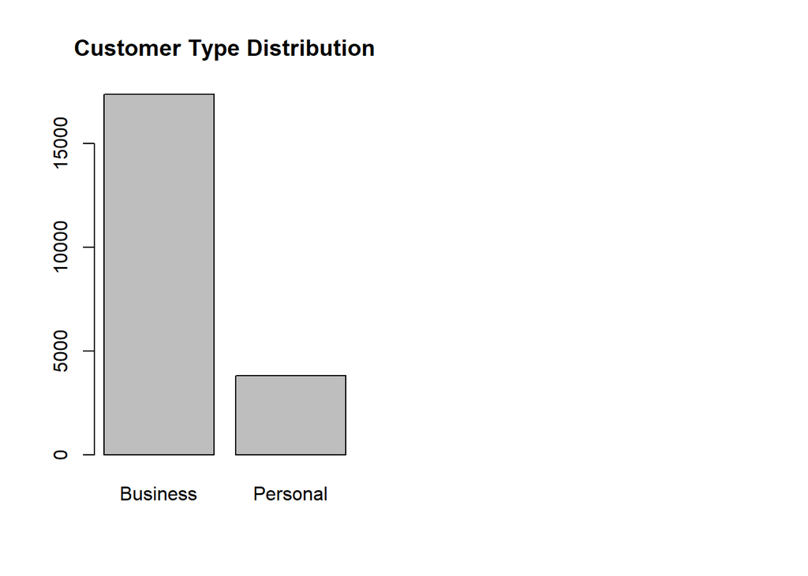

```r
par(mfrow=c(1, 2))

Customer.Type.distribution <- table(sendy$Personal.or.Business)
barplot(Customer.Type.distribution,main = "Customer Type Distribution")
```

The most popular customers are businesses.

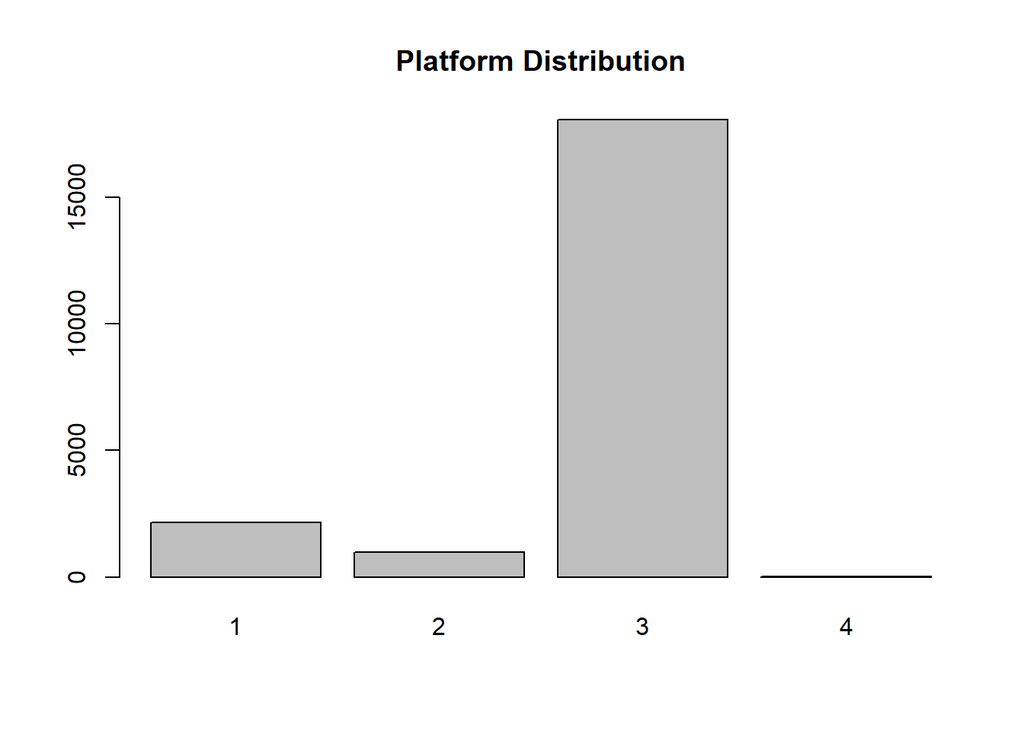

```r
Platform.distribution <- table(sendy$Platform.Type)
barplot(Platform.distribution,main = "Platform Distribution")
```

The most commonly used platform is platform 3 followed by platform 1.

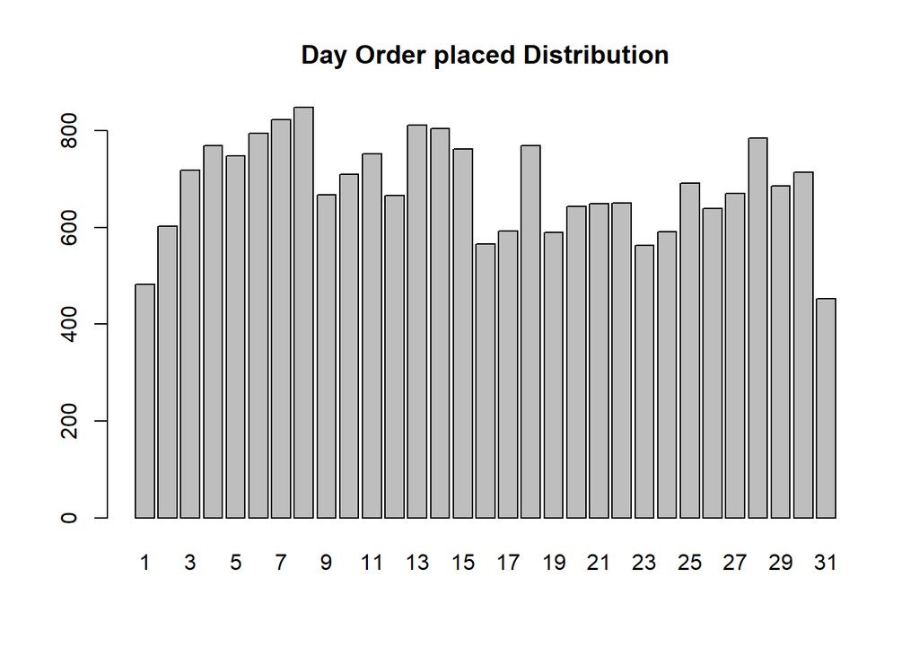

```r
Day.order.placed.distribution <- table(sendy$Placement...Day.of.Month)
barplot(Day.order.placed.distribution,main="Day Order placed Distribution")
```

```r
colnames(sendy_hr)
```

```
##  [1] "Order.No"
##  [2] "User.Id"
##  [3] "Platform.Type"
##  [4] "Personal.or.Business"
##  [5] "Placement...Day.of.Month"
##  [6] "Placement...Weekday..Mo...1."
##  [7] "Placement...Time"
##  [8] "Confirmation...Day.of.Month"
##  [9] "Confirmation...Weekday..Mo...1."
## [10] "Confirmation...Time"
## [11] "Arrival.at.Pickup...Day.of.Month"
## [12] "Arrival.at.Pickup...Weekday..Mo...1."
## [13] "Arrival.at.Pickup...Time"
## [14] "Pickup...Day.of.Month"
## [15] "Pickup...Weekday..Mo...1."
## [16] "Pickup...Time"
## [17] "Arrival.at.Destination...Day.of.Month"
## [18] "Arrival.at.Destination...Weekday..Mo...1."
## [19] "Arrival.at.Destination...Time"
## [20] "Distance..KM."
## [21] "Temperature"
## [22] "Pickup.Lat"
## [23] "Pickup.Long"
## [24] "Destination.Lat"
## [25] "Destination.Long"
## [26] "Rider.Id"
## [27] "ETA"
```

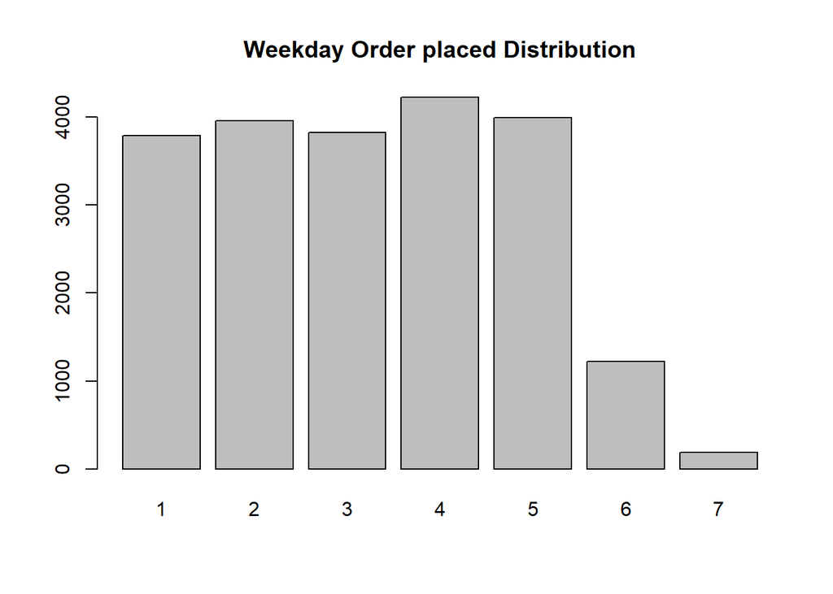

```r
Weekday.order.placed.distribution <- table(sendy_hr$Placement...Weekday..Mo...1.)
barplot(Weekday.order.placed.distribution,main="Weekday Order placed Distribution")
```

The most popular day when orders were placed was Thursday followed by Friday and Tuesday. The least popular days were Saturday and Sunday.

```r
library('plyr')
User_df=count(sendy_hr, 'User.Id')
```

```r
head(arrange(User_df, desc(freq)),10)
```

```
##         User.Id freq
## 1   User_Id_393  645
## 2  User_Id_2330  322
## 3  User_Id_3647  312
## 4  User_Id_1500  301
## 5   User_Id_635  290
## 6   User_Id_868  278
## 7  User_Id_3291  276
## 8  User_Id_3283  268
## 9   User_Id_136  211
## 10 User_Id_1329  208
```

The most recurring customer has the user id “User_Id_393”.

```r
Rider_df=count(sendy_hr, 'Rider.Id')
```

```r
head(arrange(Rider_df, desc(freq)),10)
```

```
##        Rider.Id freq
## 1  Rider_Id_726  247
## 2  Rider_Id_576  223
## 3  Rider_Id_523  199
## 4  Rider_Id_101  183
## 5  Rider_Id_205  182
## 6  Rider_Id_882  172
## 7  Rider_Id_427  168
## 8  Rider_Id_116  158
## 9   Rider_Id_88  152
## 10 Rider_Id_103  151
```

The rider with the most deliveries has the Rider Id “Rider_Id_726”.

### Univariate Analysis

```r
# A dataset description
describe(sendy_hr)
```

```
##                                            vars     n     mean      sd   median
## Order.No*                                     1 21201 10601.00 6120.35 10601.00
## User.Id*                                      2 21201  1669.86  929.01  1728.00
## Platform.Type*                                3 21201     2.75    0.63     3.00
## Personal.or.Business*                         4 21201     1.18    0.38     1.00
## Placement...Day.of.Month*                     5 21201    15.65    8.80    15.00
## Placement...Weekday..Mo...1.*                 6 21201     3.24    1.57     3.00
## Placement...Time*                             7 21201     8.33    2.54     8.00
## Confirmation...Day.of.Month*                  8 21201    15.65    8.80    15.00
## Confirmation...Weekday..Mo...1.*              9 21201     3.24    1.57     3.00
## Confirmation...Time*                         10 21201     8.45    2.56     8.00
## Arrival.at.Pickup...Day.of.Month*            11 21201    15.65    8.80    15.00
## Arrival.at.Pickup...Weekday..Mo...1.*        12 21201     3.24    1.57     3.00
## Arrival.at.Pickup...Time*                    13 21201     7.66    2.56     8.00
## Pickup...Day.of.Month*                       14 21201    15.65    8.80    15.00
## Pickup...Weekday..Mo...1.*                   15 21201     3.24    1.57     3.00
## Pickup...Time*                               16 21201     7.87    2.55     8.00
## Arrival.at.Destination...Day.of.Month*       17 21201    15.65    8.80    15.00
## Arrival.at.Destination...Weekday..Mo...1.*   18 21201     3.24    1.57     3.00
## Arrival.at.Destination...Time*               19 21201     8.30    2.57     8.00
## Distance..KM.                                20 21201     9.51    5.67     8.00
## Temperature                                  21 21201    23.26    3.22    23.26
## Pickup.Lat                                   22 21201    -1.28    0.03    -1.28
## Pickup.Long                                  23 21201    36.81    0.04    36.81
## Destination.Lat                              24 21201    -1.28    0.03    -1.28
## Destination.Long                             25 21201    36.81    0.04    36.81
## Rider.Id*                                    26 21201   461.85  274.01   461.00
## ETA                                          27 21201  1556.92  987.27  1369.00
##                                             trimmed     mad   min      max
## Order.No*                                  10601.00 7857.78  1.00 21201.00
## User.Id*                                    1686.36 1206.84  1.00  3186.00
## Platform.Type*                                 2.94    0.00  1.00     4.00
## Personal.or.Business*                          1.10    0.00  1.00     2.00
## Placement...Day.of.Month*                     15.56   11.86  1.00    31.00
## Placement...Weekday..Mo...1.*                  3.21    1.48  1.00     7.00
## Placement...Time*                              8.27    2.97  1.00    18.00
## Confirmation...Day.of.Month*                  15.56   11.86  1.00    31.00
## Confirmation...Weekday..Mo...1.*               3.21    1.48  1.00     7.00
## Confirmation...Time*                           8.40    2.97  1.00    18.00
## Arrival.at.Pickup...Day.of.Month*             15.56   11.86  1.00    31.00
```

[output cut: 29 more lines]

```
## Arrival.at.Pickup...Time*                     17.00  0.15    -0.68  0.02
## Pickup...Day.of.Month*                        30.00  0.09    -1.21  0.06
## Pickup...Weekday..Mo...1.*                     6.00  0.11    -1.03  0.01
## Pickup...Time*                                17.00  0.15    -0.69  0.02
## Arrival.at.Destination...Day.of.Month*        30.00  0.09    -1.21  0.06
## Arrival.at.Destination...Weekday..Mo...1.*     6.00  0.11    -1.03  0.01
## Arrival.at.Destination...Time*                17.00  0.14    -0.70  0.02
## Distance..KM.                                 48.00  1.08     1.46  0.04
## Temperature                                   20.90 -0.17     0.05  0.02
## Pickup.Lat                                     0.29 -0.23     0.82  0.00
## Pickup.Long                                    0.34  0.55     1.45  0.00
## Destination.Lat                                0.40  0.17     2.27  0.00
## Destination.Long                               0.41  0.41     1.34  0.00
## Rider.Id*                                    923.00 -0.02    -1.23  1.88
## ETA                                         7882.00  1.20     2.24  6.78
```

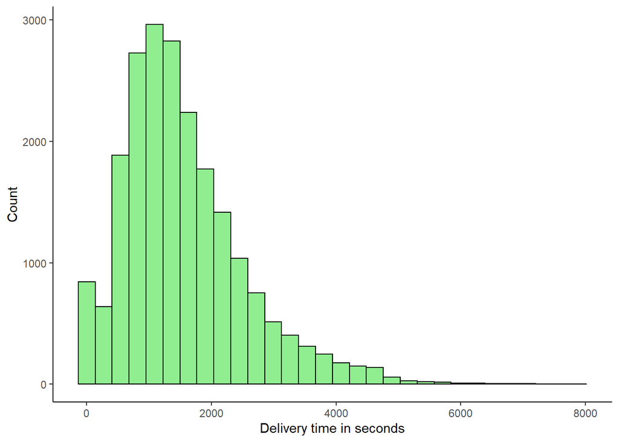

```r
ggplot(data = sendy_hr) +
  geom_histogram(mapping = aes(x = ETA),
                 fill = "lightgreen", col = "black") +
  labs(x = "Delivery time in seconds", y = "Count") +
  theme_classic()
```

```r
# Review the deliveries that took less than 5 minutes

sendy_hr = sendy_hr %>% dplyr:: filter(ETA > 5*60)
```

```r
sendy_hr %>%
  select_if(is.numeric) %>%
  map(~summary(.))
```

```
## $Distance..KM.
##    Min. 1st Qu.  Median    Mean 3rd Qu.    Max.
##   1.000   5.000   8.000   9.702  13.000  49.000
##
## $Temperature
##    Min. 1st Qu.  Median    Mean 3rd Qu.    Max.
##   11.20   21.30   23.26   23.22   25.20   32.10
##
## $Pickup.Lat
##    Min. 1st Qu.  Median    Mean 3rd Qu.    Max.
##  -1.438  -1.301  -1.279  -1.281  -1.257  -1.147
##
## $Pickup.Long
##    Min. 1st Qu.  Median    Mean 3rd Qu.    Max.
##   36.65   36.78   36.81   36.81   36.83   36.99
##
## $Destination.Lat
##    Min. 1st Qu.  Median    Mean 3rd Qu.    Max.
##  -1.430  -1.301  -1.285  -1.283  -1.261  -1.030
##
## $Destination.Long
##    Min. 1st Qu.  Median    Mean 3rd Qu.    Max.
##   36.61   36.79   36.81   36.81   36.83   37.02
##
## $ETA
##    Min. 1st Qu.  Median    Mean 3rd Qu.    Max.
##     301     954    1422    1638    2088    7883
```

```r
sendy_hr = sendy_hr %>%
  mutate(Temperature = replace_na(Temperature, mean(Temperature, na.rm = T)))
```

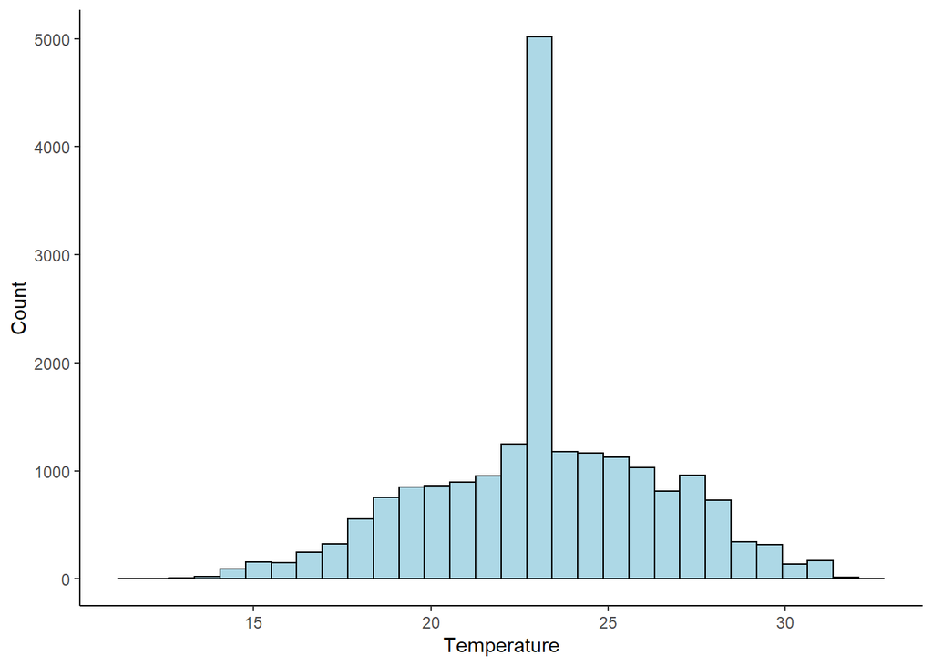

```r
ggplot(data = sendy_hr) +
  geom_histogram(mapping = aes(x = Temperature),
                 fill = "lightblue", col = "black") +
  labs(x = "Temperature", y = "Count") +
  theme_classic()
```

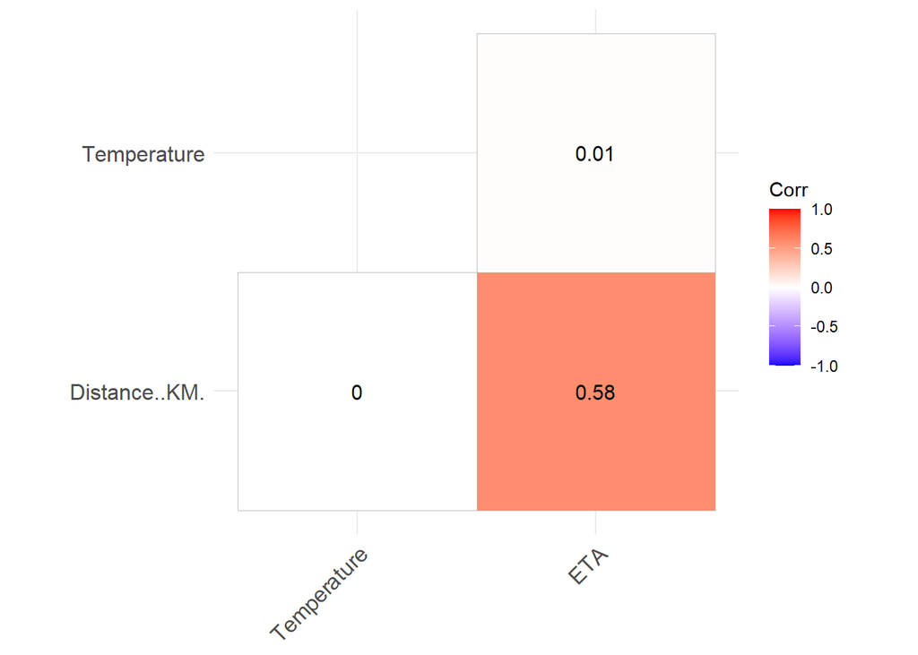

```r
# Calculate the correlations
corr <- cor(df, use = "complete.obs")
library(ggcorrplot)
ggcorrplot(round(corr, 2),
           type = "lower", lab = T)
```

## Implementing the solution

```r
# Taking a general look at the data
glimpse(sendy_hr)
```

```
## Rows: 20,107
## Columns: 27
## $ Order.No                                  <chr> "Order_No_4211", "Order_No_2~
## $ User.Id                                   <chr> "User_Id_633", "User_Id_2285~
## $ Platform.Type                             <fct> 3, 3, 3, 3, 1, 3, 3, 3, 3, 3~
## $ Personal.or.Business                      <fct> Business, Personal, Business~
## $ Placement...Day.of.Month                  <fct> 9, 12, 30, 15, 13, 14, 9, 11~
## $ Placement...Weekday..Mo...1.              <fct> 5, 5, 2, 5, 1, 5, 5, 1, 2, 5~
## $ Placement...Time                          <fct> 09, 11, 12, 09, 09, 15, 09, ~
## $ Confirmation...Day.of.Month               <fct> 9, 12, 30, 15, 13, 14, 9, 11~
## $ Confirmation...Weekday..Mo...1.           <fct> 5, 5, 2, 5, 1, 5, 5, 1, 2, 5~
## $ Confirmation...Time                       <fct> 09, 11, 12, 09, 09, 15, 09, ~
## $ Arrival.at.Pickup...Day.of.Month          <fct> 9, 12, 30, 15, 13, 14, 9, 11~
## $ Arrival.at.Pickup...Weekday..Mo...1.      <fct> 5, 5, 2, 5, 1, 5, 5, 1, 2, 5~
## $ Arrival.at.Pickup...Time                  <fct> 10, 11, 12, 09, 10, 15, 09, ~
## $ Pickup...Day.of.Month                     <fct> 9, 12, 30, 15, 13, 14, 9, 11~
## $ Pickup...Weekday..Mo...1.                 <fct> 5, 5, 2, 5, 1, 5, 5, 1, 2, 5~
## $ Pickup...Time                             <fct> 10, 11, 12, 09, 10, 15, 09, ~
## $ Arrival.at.Destination...Day.of.Month     <fct> 9, 12, 30, 15, 13, 14, 9, 11~
## $ Arrival.at.Destination...Weekday..Mo...1. <fct> 5, 5, 2, 5, 1, 5, 5, 1, 2, 5~
## $ Arrival.at.Destination...Time             <fct> 10, 12, 13, 10, 10, 16, 10, ~
## $ Distance..KM.                             <int> 4, 16, 3, 9, 9, 9, 5, 3, 9, ~
## $ Temperature                               <dbl> 20.40000, 26.40000, 23.25889~
## $ Pickup.Lat                                <dbl> -1.317755, -1.351453, -1.308~
## $ Pickup.Long                               <dbl> 36.83037, 36.89932, 36.84342~
## $ Destination.Lat                           <dbl> -1.300406, -1.295004, -1.300~
## $ Destination.Long                          <dbl> 36.82974, 36.81436, 36.82820~
## $ Rider.Id                                  <chr> "Rider_Id_432", "Rider_Id_85~
## $ ETA                                       <int> 745, 1993, 455, 1341, 1214, ~
```

```r
# Dropping columns
se = subset(sendy_hr, select = -c(Destination.Long,Destination.Lat,Pickup.Long,Pickup.Lat,Order.No))
head(se,2)
```

```
## # A tibble: 2 x 22
##   User.Id   Platform.Type Personal.or.Busi~ Placement...Day.~ Placement...Weekd~
##   <chr>     <fct>         <fct>             <fct>             <fct>
## 1 User_Id_~ 3             Business          9                 5
## 2 User_Id_~ 3             Personal          12                5
## # ... with 17 more variables: Placement...Time <fct>,
## #   Confirmation...Day.of.Month <fct>, Confirmation...Weekday..Mo...1. <fct>,
## #   Confirmation...Time <fct>, Arrival.at.Pickup...Day.of.Month <fct>,
## #   Arrival.at.Pickup...Weekday..Mo...1. <fct>, Arrival.at.Pickup...Time <fct>,
## #   Pickup...Day.of.Month <fct>, Pickup...Weekday..Mo...1. <fct>,
## #   Pickup...Time <fct>, Arrival.at.Destination...Day.of.Month <fct>,
## #   Arrival.at.Destination...Weekday..Mo...1. <fct>,
## #   Arrival.at.Destination...Time <fct>, Distance..KM. <int>,
## #   Temperature <dbl>, Rider.Id <chr>, ETA <int>
```

```r
library(CatEncoders)

# Label encode the categorical columns

# for Personal or Business
encode = LabelEncoder.fit(se$Personal.or.Business)
se$Personal.or.Business = transform(encode, se$Personal.or.Business)

# for userid
encode = LabelEncoder.fit(se$User.Id)
se$User.Id = transform(encode, se$User.Id)

# for riderid
encode = LabelEncoder.fit(se$Rider.Id)
se$Rider.Id = transform(encode, se$Rider.Id)

head(se)
```

```
## # A tibble: 6 x 22
##   User.Id Platform.Type Personal.or.Busi~ Placement...Day.o~ Placement...Weekda~
##     <int> <fct>                     <int> <fct>              <fct>
## 1    2819 3                             1 9                  5
## 2    1202 3                             2 12                 5
## 3    1546 3                             1 30                 2
## 4     377 3                             1 15                 5
## 5     685 1                             2 13                 1
## 6     317 3                             1 14                 5
## # ... with 17 more variables: Placement...Time <fct>,
## #   Confirmation...Day.of.Month <fct>, Confirmation...Weekday..Mo...1. <fct>,
## #   Confirmation...Time <fct>, Arrival.at.Pickup...Day.of.Month <fct>,
## #   Arrival.at.Pickup...Weekday..Mo...1. <fct>, Arrival.at.Pickup...Time <fct>,
## #   Pickup...Day.of.Month <fct>, Pickup...Weekday..Mo...1. <fct>,
## #   Pickup...Time <fct>, Arrival.at.Destination...Day.of.Month <fct>,
## #   Arrival.at.Destination...Weekday..Mo...1. <fct>,
## #   Arrival.at.Destination...Time <fct>, Distance..KM. <int>,
## #   Temperature <dbl>, Rider.Id <int>, ETA <int>
```

```r
tail(se)
```

```
## # A tibble: 6 x 22
##   User.Id Platform.Type Personal.or.Busi~ Placement...Day.o~ Placement...Weekda~
##     <int> <fct>                     <int> <fct>              <fct>
## 1     235 3                             1 15                 1
## 2    2412 3                             1 2                  6
## 3     737 3                             1 13                 6
## 4    1829 3                             1 7                  4
## 5    1424 1                             2 4                  3
## 6    2901 3                             1 26                 2
## # ... with 17 more variables: Placement...Time <fct>,
## #   Confirmation...Day.of.Month <fct>, Confirmation...Weekday..Mo...1. <fct>,
## #   Confirmation...Time <fct>, Arrival.at.Pickup...Day.of.Month <fct>,
## #   Arrival.at.Pickup...Weekday..Mo...1. <fct>, Arrival.at.Pickup...Time <fct>,
## #   Pickup...Day.of.Month <fct>, Pickup...Weekday..Mo...1. <fct>,
## #   Pickup...Time <fct>, Arrival.at.Destination...Day.of.Month <fct>,
## #   Arrival.at.Destination...Weekday..Mo...1. <fct>,
## #   Arrival.at.Destination...Time <fct>, Distance..KM. <int>,
## #   Temperature <dbl>, Rider.Id <int>, ETA <int>
```

```r
# Shuffle by row indices
rows <- sample(nrow(se))

# Shuffle
sendy_shuffled <- se[rows, ]
```

```r
# For reprocibility, set the seed
set.seed(0)

# Create a random order to split the data, that is if not shuffled
index <- createDataPartition(sendy_shuffled$ETA,
                                  p = 0.70, list = FALSE)
```

```r
# Create training and test sets
training <- sendy_shuffled[index, ]
testing <- sendy_shuffled[-index, ]
```

```r
# We want to be in control of validation
my_control <- trainControl(method = "cv",
                           number = 5,
                           verboseIter = FALSE)
```

```r
library(gbm)
gboost=gbm(ETA ~ . ,data = training, distribution = "gaussian",n.trees = 3000,
                  shrinkage = 0.01, interaction.depth = 4, cv.folds=5)
gboost
```

```
## gbm(formula = ETA ~ ., distribution = "gaussian", data = training,
##     n.trees = 3000, interaction.depth = 4, shrinkage = 0.01,
##     cv.folds = 5)
## A gradient boosted model with gaussian loss function.
## 3000 iterations were performed.
## The best cross-validation iteration was 2992.
## There were 21 predictors of which 15 had non-zero influence.
```

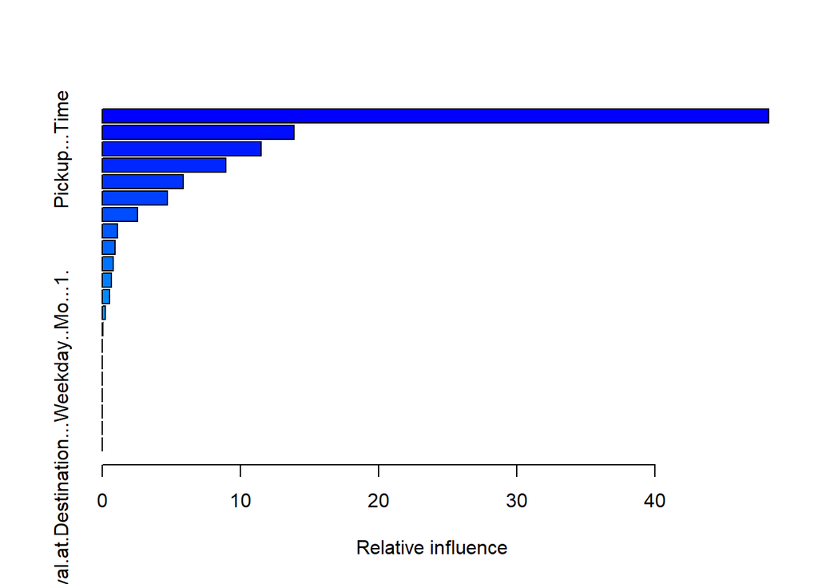

```
##                                                                                 var
## Distance..KM.                                                         Distance..KM.
## Arrival.at.Destination...Time                         Arrival.at.Destination...Time
## Pickup...Time                                                         Pickup...Time
## Placement...Day.of.Month                                   Placement...Day.of.Month
## Confirmation...Time                                             Confirmation...Time
## Arrival.at.Pickup...Time                                   Arrival.at.Pickup...Time
## Placement...Time                                                   Placement...Time
## Confirmation...Day.of.Month                             Confirmation...Day.of.Month
## Rider.Id                                                                   Rider.Id
## User.Id                                                                     User.Id
## Placement...Weekday..Mo...1.                           Placement...Weekday..Mo...1.
## Temperature                                                             Temperature
## Confirmation...Weekday..Mo...1.                     Confirmation...Weekday..Mo...1.
## Platform.Type                                                         Platform.Type
## Personal.or.Business                                           Personal.or.Business
## Arrival.at.Pickup...Day.of.Month                   Arrival.at.Pickup...Day.of.Month
## Arrival.at.Pickup...Weekday..Mo...1.           Arrival.at.Pickup...Weekday..Mo...1.
## Pickup...Day.of.Month                                         Pickup...Day.of.Month
## Pickup...Weekday..Mo...1.                                 Pickup...Weekday..Mo...1.
## Arrival.at.Destination...Day.of.Month         Arrival.at.Destination...Day.of.Month
## Arrival.at.Destination...Weekday..Mo...1. Arrival.at.Destination...Weekday..Mo...1.
##                                                rel.inf
## Distance..KM.                             48.239215832
## Arrival.at.Destination...Time             13.861790284
## Pickup...Time                             11.498621496
## Placement...Day.of.Month                   8.959464763
## Confirmation...Time                        5.855877863
## Arrival.at.Pickup...Time                   4.704540106
## Placement...Time                           2.562201976
## Confirmation...Day.of.Month                1.127880326
## Rider.Id                                   0.920449400
## User.Id                                    0.786994522
## Placement...Weekday..Mo...1.               0.665436438
## Temperature                                0.530406497
## Confirmation...Weekday..Mo...1.            0.247163195
## Platform.Type                              0.035974520
## Personal.or.Business                       0.003982781
## Arrival.at.Pickup...Day.of.Month           0.000000000
## Arrival.at.Pickup...Weekday..Mo...1.       0.000000000
## Pickup...Day.of.Month                      0.000000000
## Pickup...Weekday..Mo...1.                  0.000000000
## Arrival.at.Destination...Day.of.Month      0.000000000
## Arrival.at.Destination...Weekday..Mo...1.  0.000000000
```

```r
summary(gboost)#Summary gives a table of Variable Importance and a plot of Variable Importance
```

```r
n.trees = seq(from=100 ,to=3000, by=100) #no of trees-a vector of 100 values
```

```r
#Generating a Prediction matrix for each Tree
predmatrix<-predict(gboost,testing,n.trees =n.trees )
dim(predmatrix) #dimensions of the Prediction Matrix
```

```
## [1] 6031   30
```

```r
test.error<-with(testing,apply( (predmatrix-ETA)^2,2,mean))
head(test.error)
```

```
##      100      200      300      400      500      600
## 650280.4 598636.7 568584.5 548648.2 531006.5 515494.0
```

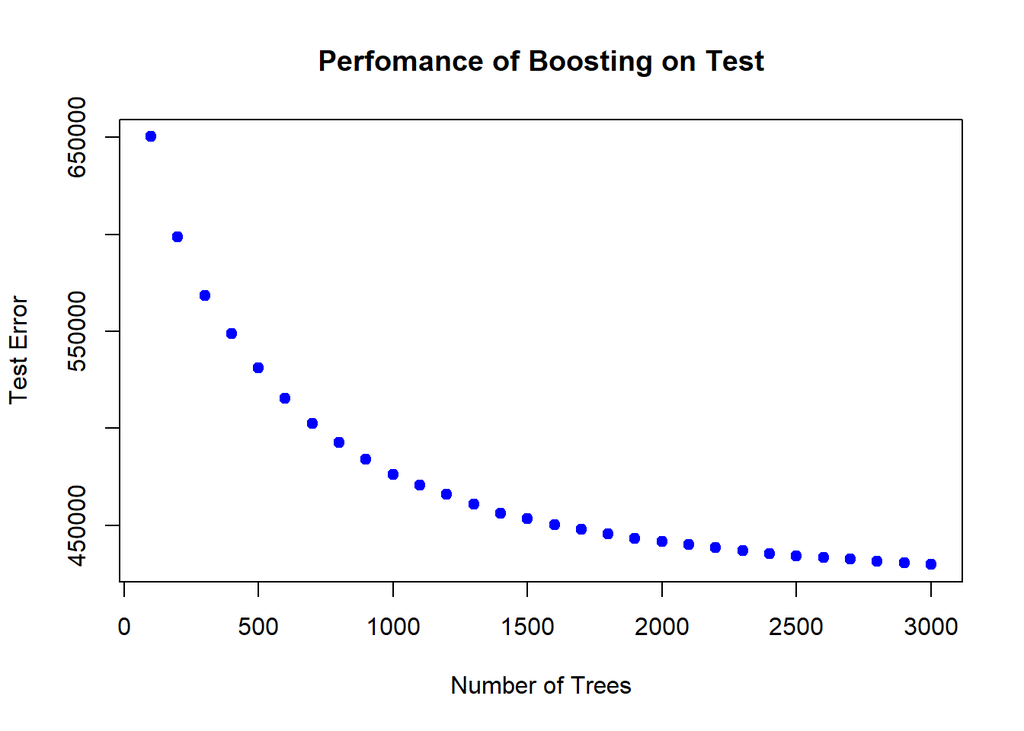

```r
plot(n.trees , test.error , pch=19,col="blue",xlab="Number of Trees",ylab="Test Error", main = "Perfomance of Boosting on Test")
```

```r
# selecting the features for our subset with influence > 1
training = subset(training, select = c(Distance..KM.,Arrival.at.Destination...Time,Pickup...Time,Placement...Day.of.Month,Confirmation...Time,Confirmation...Day.of.Month,Placement...Time,Arrival.at.Pickup...Time,ETA))
testing = subset(testing, select = c(Distance..KM.,Arrival.at.Destination...Time,Pickup...Time,Placement...Day.of.Month,Confirmation...Time,Confirmation...Day.of.Month,Placement...Time,Arrival.at.Pickup...Time,ETA))
```

```r
# Fit the model
lm_model <- suppressWarnings(suppressMessages(train(ETA~ .,
                  data = training,
                  method = 'lm',
                  trControl = my_control)))


lm_model
```

```
## Linear Regression
##
## 14076 samples
##     8 predictor
##
## No pre-processing
## Resampling: Cross-Validated (5 fold)
## Summary of sample sizes: 11260, 11262, 11261, 11260, 11261
## Resampling results:
##
##   RMSE      Rsquared   MAE
##   666.2965  0.5050477  489.0365
##
## Tuning parameter 'intercept' was held constant at a value of TRUE
```

```r
predicted <- predict(lm_model, testing)
library(xgboost)
xgb_model <- suppressWarnings(suppressMessages(train(ETA~ .,
                  data = training,
                  method = 'xgbTree',
                  trControl = my_control)))
```

```r
colMeans(xgb_model$results)%>% as.data.frame()
```

```
##                             .
## eta                0.35000000
## max_depth          2.00000000
## gamma              0.00000000
## colsample_bytree   0.70000000
## min_child_weight   1.00000000
## subsample          0.75000000
## nrounds          100.00000000
## RMSE             688.44194695
## Rsquared           0.46994532
## MAE              491.43683133
## RMSESD            13.27519203
## RsquaredSD         0.01560257
## MAESD              7.14283384
```

```r
xgb_model$results[108,]
```

```
##     eta max_depth gamma colsample_bytree min_child_weight subsample nrounds
## 108 0.4         3     0              0.8                1         1     150
##         RMSE  Rsquared      MAE   RMSESD RsquaredSD   MAESD
## 108 638.0091 0.5465468 463.4817 16.26001 0.01568182 9.54393
```

### Unsupervised learning

```r
library(factoextra)
```

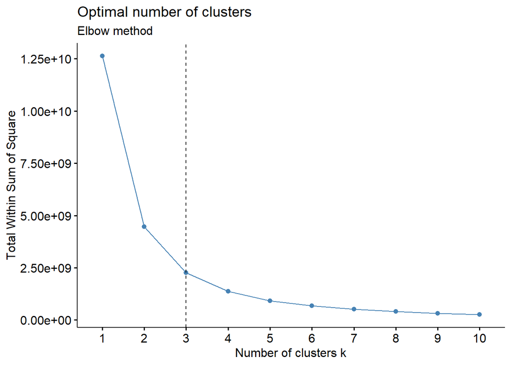

```r
# Elbow method
fviz_nbclust(training, kmeans, method = "wss") +
    geom_vline(xintercept = 3, linetype = 2)+
  labs(subtitle = "Elbow method")
```

```r
#implementing the Kmeans using 3 clusters as suggested by majority of the methods
km <- kmeans(training,3,iter.max = 10, nstart = 50)
```

[output not shown]

[output not shown]